# Explore biodiversity with NEON algae data

## Learning Objectives

After completing this tutorial you will be able to:

- Use the ecocomDP package to download NEON algae data.
- Analyze biodiversity metrics using the `vegan` package

## Things You’ll Need To Complete This Tutorial

### R Programming Language

You will need a current version of R to complete this tutorial. We also recommend the RStudio IDE to work with R.

### R Packages to Install

Prior to starting the tutorial ensure that the following packages are installed.

- **tidyverse:** `install.packages("tidyverse")`
- **neonUtilities:** `install.packages("neonUtilities")`
- **devtools:** `install.packages("devtools")`
- **vegan:** `install.packages("vegan")`

[More on Packages in R](https://www.neonscience.org/packages-in-r) – Adapted from Software Carpentry.

## Introduction

In this second live coding section of the workshop, we will explore how to find and download NEON biodiversity data using the ecocomDP package for R, which is under development by the Environmental Data Initiative (EDI).

#### What is ecocomDP?

ecocomDP is both the name of an R package and a data model.

EDI describes the ecocomDP data model as “A dataset design pattern for ecological community data to facilitate synthesis and reuse”.

See the ecocomDP github repo here: https://github.com/EDIorg/ecocomDP.

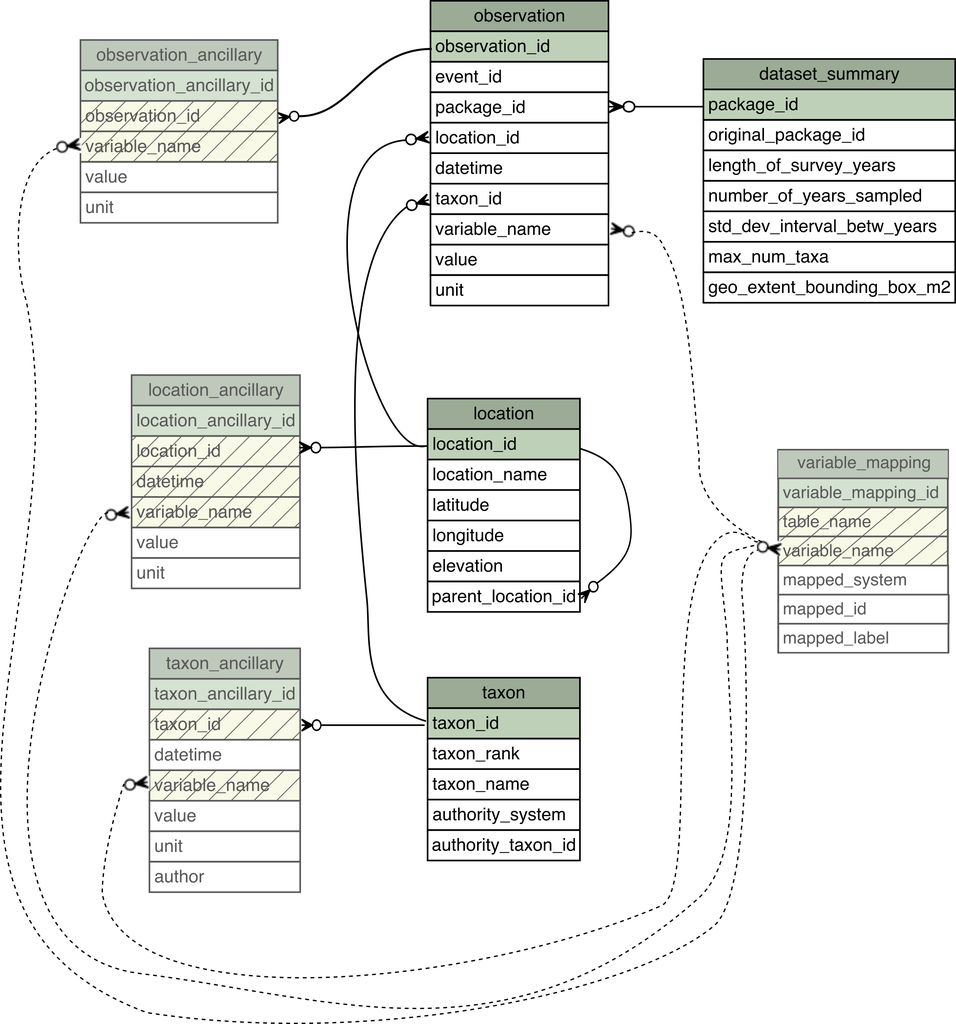

Data model workflow showing relationships between various tables in ecocomDP model. Source: EDIorg

The motivation is for both NEON biodiversity data products and EDI data packages, including data from the US Long Term Ecological Research Network and Macrosystems Biology projects, to be discoverable through a single data search tool, and to be delivered in a standard format. Our objective here is to demonstrate how the workflow will work with NEON biodiversity data packages.

This tutorial was prepared for the [Society for Freshwater Science 2021 NEON Aquatic Biodiversity Workshop](https://www.neonscience.org/get-involved/events/sfs-2021-neon-aquatic-biodiversity-workshop).

## Load Libraries and Prepare Workspace

First, we will load all necessary libraries into our R environment. If you have not already installed these libraries, please see the ‘R Packages to Install’ section above. We load the `devtools` package here so that we can install the latest development version of the ecocomDP package from the GitHub repository. The ecocomDP package is not yet available through CRAN, and therefore, we must install the package in this manner.

There are also two optional sections in this code chunk: clearing your environment, and loading your NEON API token. Clearing out your environment will erase *all* of the variables and data that are currently loaded in your R session. This is a good practice for many reasons, but only do this if you are completely sure that you won’t be losing any important information! Secondly, your NEON API token will allow you increased download speeds, and helps NEON **anonymously** track data usage statistics, which helps us optimize our data delivery platforms, and informs our monthly and annual reporting to our funding agency, the National Science Foundation. Please consider signing up for a NEON data user account, and using your token [as described in this tutorial here](https://www.neonscience.org/neon-api-tokens-tutorial).

```r
# clean out workspace

#rm(list = ls()) # OPTIONAL - clear out your environment
#gc()            # Uncomment these lines if desired

# load packages
library(tidyverse)
library(neonUtilities)
library(devtools)
library(vegan)

# install ecocomDP
# Here, we're using a tagged (pre-release) version of the
# package that's available on GitHub. Using this tag
# (@v.0.0.0.9000) will always install the same version
# of the package. We plan to release v1.0 of this package
# on CRAN later this year.
devtools::install_github("EDIorg/ecocomDP@v0.0.0.9000")
library(ecocomDP)

# source .r file with my NEON_TOKEN
# source("my_neon_token.R") # OPTIONAL - load NEON token
# See: https://www.neonscience.org/neon-api-tokens-tutorial
```

## Download Macroinvertibrate Data

In this first step, we show how to search the ecocomDP database for macroinvertibrate data including those from LTER and NEON sites (and others).

```r
# search for invertebrate data products
my_search_result <-
    ecocomDP::search_data(text = "invertebrate")
View(my_search_result)

# pull data for the NEON aquatic "Macroinvertebrate
# collection"
my_data <- ecocomDP::read_data(
  id = "neon.ecocomdp.20120.001.001",
  site = c('ARIK','MAYF'),
  startdate = "2017-06",
  enddate = "2020-03",
  # token = NEON_TOKEN, #Uncomment to use your token
  check.size = FALSE)
```

Now that we have downloaded the data, let’s take a look at tht `ecocomDP` data object structure:

```r
# examine the structure of the data object that is returned
my_data %>% names()
```

```
## [1] "neon.ecocomdp.20120.001.001"
```

```r
my_data$neon.ecocomdp.20120.001.001 %>% names()
```

```
## [1] "metadata"          "tables"            "validation_issues"
```

```r
# short list of package summary data
my_data$neon.ecocomdp.20120.001.001$metadata$data_package_info
```

```
## $data_package_id
## [1] "neon.ecocomdp.20120.001.001.20210519123732"
##
## $taxonomic_group
## [1] "MACROINVERTEBRATES"
##
## $orig_NEON_data_product_id
## [1] "DP1.20120.001"
##
## $NEON_to_ecocomDP_mapping_method
## [1] "neon.ecocomdp.20120.001.001"
##
## $data_access_method
## [1] "original NEON data accessed using neonUtilities v2.0.1"
##
## $data_access_date_time
## [1] "2021-05-19 12:37:36 MDT"
```

```r
# validation issues? None if returns an empty list
my_data$neon.ecocomdp.20120.001.001$validation_issues
```

```
## list()
```

```r
# examine the tables
my_data$neon.ecocomdp.20120.001.001$tables %>% names()
```

```
## [1] "location"              "location_ancillary"    "taxon"
## [4] "observation"           "observation_ancillary" "dataset_summary"
```

```r
my_data$neon.ecocomdp.20120.001.001$tables$taxon %>% head()
```

```
##   taxon_id taxon_rank           taxon_name
## 1   ABLMAL    species Ablabesmyia mallochi
## 2    ABLSP      genus      Ablabesmyia sp.
## 3   ACASP1   subclass            Acari sp.
## 4   ACEPYG    species    Acerpenna pygmaea
## 5   ACESP1      genus        Acerpenna sp.
## 6   ACRABN    species  Acroneuria abnormis
##                                                                                                                        authority_system
## 1                                                                                               Epler 2001, and Maschwitz and Cook 2000
## 2 Roback 1985 and Epler 2001; Weiderholm, 1983; Weiderholm, 1986; Epler 2001; Ferrington et al. 2019; Andersen, Cranston and Epler 2013
## 3                                                                                          Thorp and Covich 2001; Thorp and Rogers 2016
## 4                                                                                                          Morihara and McCafferty 1979
## 5                                                                                                                   Merritt et al. 2019
## 6                                                                                                               Stewart and Stark, 2002
##   authority_taxon_id
## 1               <NA>
## 2               <NA>
## 3               <NA>
## 4               <NA>
## 5               <NA>
## 6               <NA>
```

```r
my_data$neon.ecocomdp.20120.001.001$tables$observation %>% head()
```

```
##   observation_id             event_id
## 1          obs_1 ARIK.20170712.CORE.1
## 2          obs_2 ARIK.20170712.CORE.1
## 3          obs_3 ARIK.20170712.CORE.1
## 4          obs_4 ARIK.20170712.CORE.1
## 5          obs_5 ARIK.20170712.CORE.1
## 6          obs_6 ARIK.20170712.CORE.1
##                                   package_id    location_id   datetime taxon_id
## 1 neon.ecocomdp.20120.001.001.20210519123732 ARIK.AOS.reach 2017-07-12   CAESP5
## 2 neon.ecocomdp.20120.001.001.20210519123732 ARIK.AOS.reach 2017-07-12  CERSP10
## 3 neon.ecocomdp.20120.001.001.20210519123732 ARIK.AOS.reach 2017-07-12   CLASP5
## 4 neon.ecocomdp.20120.001.001.20210519123732 ARIK.AOS.reach 2017-07-12   CLISP3
## 5 neon.ecocomdp.20120.001.001.20210519123732 ARIK.AOS.reach 2017-07-12   CORSP4
## 6 neon.ecocomdp.20120.001.001.20210519123732 ARIK.AOS.reach 2017-07-12   CRYSP2
##   variable_name     value                   unit
## 1       density 1000.0000 count per square meter
## 2       density  333.3333 count per square meter
## 3       density  333.3333 count per square meter
## 4       density  333.3333 count per square meter
## 5       density  166.6667 count per square meter
## 6       density  833.3333 count per square meter
```

## Search ecocomDP

We can even search for terms in the ecocomDP database using regular expressions:

```r
# search for data sets with periphyton or algae
# regex works!
my_search_result <- ecocomDP::search_data(text = "periphyt|algae")
```

```
## Searching data ...
```

```r
View(my_search_result)
```

Let’s download the data for the NEON “Periphyton, seston, and phytoplankton collection” from “ARIK” and view its structure:

```r
# pull data for the NEON "Periphyton, seston, and phytoplankton collection"
# data product
my_data <-
    ecocomDP::read_data(
      id = "neon.ecocomdp.20166.001.001",
      site = "ARIK",
      startdate = "2017-06",
      enddate = "2020-03",
      # token = NEON_TOKEN, #Uncomment to use your token
      check.size = FALSE)
```

```r
# Explore the structure of the returned data object
my_data %>% names()
```

```
## [1] "neon.ecocomdp.20166.001.001"
```

```r
my_data[[1]] %>% names()
```

```
## [1] "metadata"          "tables"            "validation_issues"
```

```r
my_data[[1]]$metadata$data_package_info
```

```
## $data_package_id
## [1] "neon.ecocomdp.20166.001.001.20210519123757"
##
## $taxonomic_group
## [1] "ALGAE"
##
## $orig_NEON_data_product_id
## [1] "DP1.20166.001"
##
## $NEON_to_ecocomDP_mapping_method
## [1] "neon.ecocomdp.20166.001.001"
##
## $data_access_method
## [1] "original NEON data accessed using neonUtilities v2.0.1"
##
## $data_access_date_time
## [1] "2021-05-19 12:37:57 MDT"
```

```r
my_data[[1]]$validation_issues
```

```
## list()
```

```r
my_data[[1]]$tables %>% names()
```

```
## [1] "location"              "location_ancillary"    "taxon"
## [4] "observation"           "observation_ancillary" "dataset_summary"
```

```r
my_data[[1]]$tables$location
```

```
##      location_id  location_name latitude longitude elevation parent_location_id
## 1            D10 Central Plains       NA        NA        NA               <NA>
## 2           ARIK Arikaree River 39.75825 -102.4471        NA                D10
## 3 ARIK.AOS.reach ARIK.AOS.reach 39.75821 -102.4471    1179.5               ARIK
## 4    ARIK.AOS.S2    ARIK.AOS.S2 39.75836 -102.4486    1178.7               ARIK
```

```r
my_data[[1]]$tables$taxon %>% head()
```

```
##           taxon_id taxon_rank            taxon_name
## 1 ACHNANTHIDIUMSPP      genus    Achnanthidium spp.
## 2       AMPHORASPP      genus          Amphora spp.
## 3      ANABAENASPP      genus         Anabaena spp.
## 4   AULACOSEIRASPP      genus      Aulacoseira spp.
## 5    BACILLARIOCSP      class Bacillariophyceae sp.
## 6      CALONEISSPP      genus         Caloneis spp.
##                                                                                                                                                                                                                                           authority_system
## 1                                                   Academy of Natural Sciences of Drexel University and collaborators. 2011 - 2016. ANSP/NAWQA/EPA 2011 diatom and non-diatom taxa names, http://diatom.ansp.org/nawqa/Taxalist.aspx, accessed 1/11/2016.
## 2                                                   Academy of Natural Sciences of Drexel University and collaborators. 2011 - 2016. ANSP/NAWQA/EPA 2011 diatom and non-diatom taxa names, http://diatom.ansp.org/nawqa/Taxalist.aspx, accessed 1/11/2016.
## 3                                                   Academy of Natural Sciences of Drexel University and collaborators. 2011 - 2016. ANSP/NAWQA/EPA 2011 diatom and non-diatom taxa names, http://diatom.ansp.org/nawqa/Taxalist.aspx, accessed 1/11/2016.
## 4                                                   Academy of Natural Sciences of Drexel University and collaborators. 2011 - 2016. ANSP/NAWQA/EPA 2011 diatom and non-diatom taxa names, http://diatom.ansp.org/nawqa/Taxalist.aspx, accessed 1/11/2016.
## 5 Academy of Natural Sciences of Drexel University; Academy of Natural Sciences of Drexel University and collaborators. 2011 - 2016. ANSP/NAWQA/EPA 2011 diatom and non-diatom taxa names, http://diatom.ansp.org/nawqa/Taxalist.aspx, accessed 1/11/2016.
## 6                                                   Academy of Natural Sciences of Drexel University and collaborators. 2011 - 2016. ANSP/NAWQA/EPA 2011 diatom and non-diatom taxa names, http://diatom.ansp.org/nawqa/Taxalist.aspx, accessed 1/11/2016.
##   authority_taxon_id
## 1               <NA>
## 2               <NA>
## 3               <NA>
## 4               <NA>
## 5               <NA>
## 6               <NA>
```

```r
my_data[[1]]$tables$observation %>% head()
```

```
##                         observation_id                  event_id
## 1 2f9cd348-0767-4322-b7b8-19182778a98c ARIK.20170718.EPIPHYTON.3
## 2 fcb13e4f-2cf6-4d97-9c70-09a70f51fb7e ARIK.20170718.EPIPHYTON.3
## 3 c2a8fcf8-1cf2-42da-868b-077ea1726433 ARIK.20170718.EPIPHYTON.3
## 4 6c0a36d3-0075-4d17-bc0a-03b35cb5f179 ARIK.20170718.EPIPHYTON.3
## 5 6493f9e6-d1b6-42fd-9156-bb4fb97b2854 ARIK.20170718.EPIPHYTON.3
## 6 63ed13f7-f9ee-46b9-aea4-2fc2c3cfdd09 ARIK.20170718.EPIPHYTON.3
##                                   package_id    location_id   datetime
## 1 neon.ecocomdp.20166.001.001.20210519123757 ARIK.AOS.reach 2017-07-18
## 2 neon.ecocomdp.20166.001.001.20210519123757 ARIK.AOS.reach 2017-07-18
## 3 neon.ecocomdp.20166.001.001.20210519123757 ARIK.AOS.reach 2017-07-18
## 4 neon.ecocomdp.20166.001.001.20210519123757 ARIK.AOS.reach 2017-07-18
## 5 neon.ecocomdp.20166.001.001.20210519123757 ARIK.AOS.reach 2017-07-18
## 6 neon.ecocomdp.20166.001.001.20210519123757 ARIK.AOS.reach 2017-07-18
##         taxon_id variable_name     value      unit
## 1  NEONDREX48126  cell density 1180.3455 cells/cm2
## 2  NEONDREX33185  cell density  295.0864 cells/cm2
## 3 NEONDREX197003  cell density  147.5409 cells/cm2
## 4 NEONDREX170133  cell density  590.1727 cells/cm2
## 5  NEONDREX37156  cell density  295.0864 cells/cm2
## 6 NEONDREX155017  cell density 2655.7727 cells/cm2
```

## Algae Data Flattening and Cleaning

While the ecocomDP data package takes care of some data cleaning and formatting, it is best to join all the tables and flatten the dataset and do some basic checks before proceeding with plotting and analyses:

```r
# flatten the ecocomDP data tables into one flat table
my_data_flat <- my_data[[1]]$tables %>% ecocomDP::flatten_data()

# This data product has algal densities reported for both
# lakes and streams, so densities could be standardized
# either to volume collected or area sampled.

# Verify that only benthic algae standardized to area
# are returned in this data pull:
my_data_flat$unit %>%
    unique()
```

```
## [1] "cells/cm2" "cells/mL"
```

```r
# filter the data to only records standardized to area
# sampled
my_data_benthic <- my_data_flat %>%
  dplyr::filter(
    !variable_name %in% c("valves","cells"),
    unit == "cells/cm2")

# Note that for this data product
# neon_sample_id = event_id
# event_id is the grouping variable for the observation
# table in the ecocomDP data model



# Check for multiple taxon counts per taxon_id by
# event_id.
my_data_benthic %>%
  group_by(event_id, taxon_id) %>%
  summarize(n_obs = length(event_id)) %>%
  dplyr::filter(n_obs > 1)
```

```
## # A tibble: 37 x 3
## # Groups:   event_id [2]
##    event_id                  taxon_id       n_obs
##    <chr>                     <chr>          <int>
##  1 ARIK.20170718.EPIPHYTON.2 NEONDREX1010       2
##  2 ARIK.20170718.EPIPHYTON.2 NEONDREX1024       2
##  3 ARIK.20170718.EPIPHYTON.2 NEONDREX110005     2
##  4 ARIK.20170718.EPIPHYTON.2 NEONDREX155017     2
##  5 ARIK.20170718.EPIPHYTON.2 NEONDREX16004      2
##  6 ARIK.20170718.EPIPHYTON.2 NEONDREX16011      2
##  7 ARIK.20170718.EPIPHYTON.2 NEONDREX170133     2
##  8 ARIK.20170718.EPIPHYTON.2 NEONDREX170134     2
##  9 ARIK.20170718.EPIPHYTON.2 NEONDREX172001     2
## 10 ARIK.20170718.EPIPHYTON.2 NEONDREX172006     2
## # ... with 27 more rows
```

```r
# Per instructions from the lab, these
# counts should be summed.
my_data_summed <- my_data_benthic %>%
  group_by(event_id,taxon_id) %>%
  summarize(value = sum(value, na.rm = FALSE))

my_data_cleaned <- my_data_benthic %>%
  dplyr::select(
    event_id, location_id, datetime,
    taxon_id, taxon_rank, taxon_name) %>%
  distinct() %>%
  right_join(my_data_summed)



# check for duplicate records, there should not
# be any at this point.
my_data_cleaned %>%
  group_by(event_id, taxon_id) %>%
  summarize(n_obs = length(event_id)) %>%
  dplyr::filter(n_obs > 1)
```

```
## # A tibble: 0 x 3
## # Groups:   event_id [0]
## # ... with 3 variables: event_id <chr>, taxon_id <chr>, n_obs <int>
```

We can also make a quick plot to see which taxon rank (i.e., what level of taxonomic specificity was achieved by the expert taxonomist) is most common:

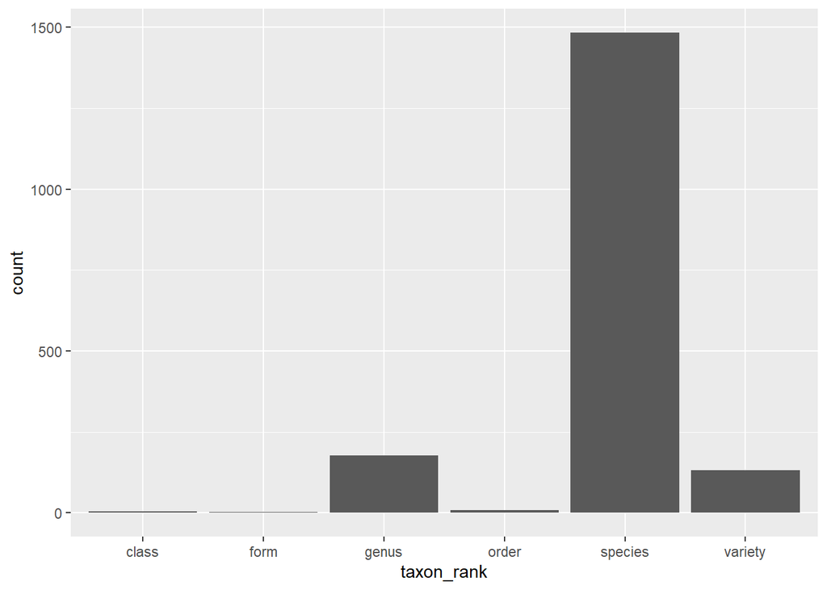

Bar plot showing the frequency of each taxonomic rank observed in algae count data from the Arikaree River site.

```r
# which taxon rank is most common
my_data_cleaned %>%
  ggplot(aes(taxon_rank)) +
  geom_bar()
```